# How can we Better Facillitate the Shift to Clean Energy?

Lizzie Kriz

2026-02-10

# Sustainable Development Goals

Out of the 17 UN Sustainable Development Goals, efforts that work towards shifting away from fossil fuels and instead exploring and bettering clean energy work to fulfill at least three of them:

1.**Affordable & Clean Energy**

2.Sustainable Cities & Communities

3.Climate Action

The first would be the direct result while the remaining 2, and arguably more SDGs, would be an indirect result of enhancing affordable and clean energy.

## Emissions

First, let’s take a look at the **big picture**. For simplicity’s sake, we are just looking at a handful of countries to serve as a microcosm of how we might deal with all of the world’s countries and their unique strengths, weaknesses, and opportunities for *improvement*.

[interactive chart not shown]

## Economic Context

For some important context lets look at the economic state of these countries. This will provide us *insight* into the current state of the country and the opportunities, or lack thereof, that could be pursued.

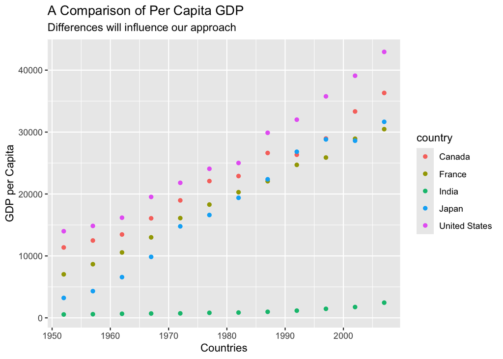

## Fuel cost comparisons

Since there is an economic disparity between the two countries we are targeting, lets look at the affordability of our clean energy options.

[interactive chart not shown]

Historically, using clean energy would simply not be practical or sustainable for developing countries with less resources, and using Fossil Fuels would have been the only viable option. However, with these advancements, integrating more clean energy sources would not be as costly.

| Source | Cost |
| --- | --- |
| Concentrated solar power | 0.107 |
| Offshore wind | 0.086 |
| Bioenergy | 0.072 |
| Solar photovoltaic | 0.064 |
| Geothermal | 0.054 |
| Hydropower | 0.046 |
| Onshore wind | 0.045 |

Looking at these costs, the most cost-effective clean energy implementations for India would be **Hydroelectric** & **Onshore Wind**.

- India’s **Hydroelectric** potential is mostly unfulfilled at this point, with only 29% developed. The Himalayan regions are an untapped source, which could increase their capacity greatly. There are currently several projects underway that aim to take advantage of these opportunities.
- India’s **Onshore wind** market is currently ranked fourth-largest in the world! Producing roughly 51GW (enough to power ~45 million homes).

## Fuel Production Comparisons

The United States’ GDP is **not** a limiting factor as it is for India; in this case, we should examine which power source(s) will deliver the best “bang for our buck”.

| Technology | Electricity statistics |
| --- | --- |
| Total renewable | 959231.98 |
| Solar photovoltaic | 183812.46 |
| Onshore wind energy | 439125.51 |
| Offshore wind energy | 144.72 |
| Renewable hydropower | 256601.19 |
| Biogas | 10258.04 |
| Geothermal energy | 19142.16 |
| Total non-renewable | 3536136.13 |
| Coal and peat | 913301.90 |
| Oil | 42512.71 |
| Natural gas | 1740420.84 |
| Nuclear | 803668.57 |

- **Onshore Wind** is a leading renewable energy source in the US with 9,124 GW of potential capacity, and 150 GW currently installed.
- The US’s **Solar Power** has grown 28% annually, making it a huge source of clean energy. In 2024, a new solar project was installed every 54 seconds, totaling 5,561,319 solar energy systems in the U.S.

## Data Sources

- [Carbon Data](https://nyc3.digitaloceanspaces.com/owid-public/data/co2/owid-co2-data.csv)
- [Econ Data](https://raw.githubusercontent.com/ericmkeen/sewanee_esus/master/02_energy_sector/levelized-cost-of-energy.csv)
- [India’s Hydroelectric Development](https://economictimes.indiatimes.com/industry/renewables/hydroelectric-surge-india-on-the-cusp-of-a-significant-transformation-in-its-energy-sector/arti%20leshow/109082674.cms?from=md)
- [India’s Onshore Wind Develpoment](https://www.tatapower.com/blogs/onshore-and-offshore-wind-energy-partners-in-renewable-energy#:~:text=In%20India%2C%20the%20outlook%20is,of%20the%20first%20offshore%20farms.)
- [GW conversion references](https://www.energysage.com/electricity/house-watts/)
- [Solar + Onshore wind Power in the US](https://css.umich.edu/publications/factsheets/energy/us-renewable-energy-factsheet)